# Food security of vulnerable Amazonian populations affected by large hydroelectric dams

## Data

```r
library(readxl)
data<- read_excel("data_yes.xlsx",sheet = 1)
data$DATA=as.Date(data$DATA,format="%y-%m-%d")
data$TOTAL_RIQUEZA_PEIXES=as.numeric(data$TOTAL_RIQUEZA_PEIXES)
data$`Total_Peixes(g)`=as.numeric(data$`Total_Peixes(g)`)
head(data)
```

```
## # A tibble: 6 × 15
##   CODIGO MUNICI…¹ LOCAL…² INFLU…³ AREA_…⁴ ZONA    ANO DATA       NUMER…⁵ REFEI…⁶
##    <dbl> <chr>    <chr>   <chr>   <chr>   <chr> <dbl> <date>       <dbl> <chr>
## 1      1 ALTAMIRA ATM     RESERV… MONTAN… URBA…  2013 2013-05-17       8 CAFE D…
## 2      2 ALTAMIRA ATM     RESERV… MONTAN… URBA…  2013 2013-05-17       8 ALMOCO
## 3      3 ALTAMIRA ATM     RESERV… MONTAN… URBA…  2013 2013-05-17       5 MEREND…
## 4      4 ALTAMIRA ATM     RESERV… MONTAN… URBA…  2013 2013-05-18       5 CAFE D…
## 5      5 ALTAMIRA ATM     RESERV… MONTAN… URBA…  2013 2013-05-18       8 ALMOCO
## 6      6 ALTAMIRA ATM     RESERV… MONTAN… URBA…  2013 2013-05-19       6 CAFE D…
## # … with 5 more variables: TOTAL_RIQUEZA_PEIXES <dbl>, `Total_Peixes(g)` <dbl>,
## #   Season <chr>, Outros <dbl>, MEI <dbl>, and abbreviated variable names
## #   ¹MUNICIPIO, ²LOCALIDADE, ³INFLUENCIA, ⁴AREA_VAZ, ⁵NUMERO.DE.PESSSOAS,
## #   ⁶REFEICAO
```

**Including river level rate covariable:** code for merging both data sets.

```r
vazao <- read_excel("Dados_Cota_BM.xlsx",sheet=5)

vazao$DATA=as.Date(vazao$DATA,format="%y-%m-%d")

names_d=unique(data$INFLUENCIA)
names_v=unique(vazao$cod)



aa=subset(vazao, vazao$cod=="Jusante")
aa$cod=rep("DOWNSTREAM_RURAL",dim(aa)[1])
vazao=rbind(vazao,aa)


ind1=which(vazao$cod=="Jusante")
vazao[ind1,3]="DOWNSTREAM_URBAN"

ind1=which(vazao$cod=="Reservatório")
vazao[ind1,3]="RESERVOIR_RURAL"


ind1=which(vazao$cod=="VoltaGrande")
vazao[ind1,3]="DEWATERED_REACH_RURAL"

ind1=which(vazao$cod=="RESERVOIR_RURAL")
aux=vazao[ind1,]
aux[,3]="RESERVOIR_URBAN"
vazao=rbind(vazao, aux)

colnames(vazao)=c("Codigo", "Estacion", "cod",  "DATA", "ANO",  "MES",  "Cota(cm)")
vazao$newdate=(vazao$DATA)
data$newdate=(data$DATA)
l=dim(data)[1]

data$vazao=1:l
j=dim(data)[2]

for(i in 1:l){
  f=data[i,]$newdate
  a=data[i,]$INFLUENCIA
  b=subset(vazao,vazao$newdate==f)
  c=subset(b,b$cod==a)
  if(dim(c)[1]>0) {data[i,j]=c$`Cota(cm)`} else {data[i,j]=NA}
}
head(data)
```

```
## # A tibble: 6 × 17
##   CODIGO MUNICI…¹ LOCAL…² INFLU…³ AREA_…⁴ ZONA    ANO DATA       NUMER…⁵ REFEI…⁶
##    <dbl> <chr>    <chr>   <chr>   <chr>   <chr> <dbl> <date>       <dbl> <chr>
## 1      1 ALTAMIRA ATM     RESERV… MONTAN… URBA…  2013 2013-05-17       8 CAFE D…
## 2      2 ALTAMIRA ATM     RESERV… MONTAN… URBA…  2013 2013-05-17       8 ALMOCO
## 3      3 ALTAMIRA ATM     RESERV… MONTAN… URBA…  2013 2013-05-17       5 MEREND…
## 4      4 ALTAMIRA ATM     RESERV… MONTAN… URBA…  2013 2013-05-18       5 CAFE D…
## 5      5 ALTAMIRA ATM     RESERV… MONTAN… URBA…  2013 2013-05-18       8 ALMOCO
## 6      6 ALTAMIRA ATM     RESERV… MONTAN… URBA…  2013 2013-05-19       6 CAFE D…
## # … with 7 more variables: TOTAL_RIQUEZA_PEIXES <dbl>, `Total_Peixes(g)` <dbl>,
## #   Season <chr>, Outros <dbl>, MEI <dbl>, newdate <date>, vazao <int>, and
## #   abbreviated variable names ¹MUNICIPIO, ²LOCALIDADE, ³INFLUENCIA, ⁴AREA_VAZ,
## #   ⁵NUMERO.DE.PESSSOAS, ⁶REFEICAO
```

## Previous steps

### Check TOTAL_RIQUEZA_PEIXES

After replacing 0 by NA when `Total_Peixes(g)`>0 and 1 by NA when `Total_Peixes(g)`=0.

- Values of TOTAL_RIQUEZA_PEIXES if `Total_Peixes(g)`=0.

```r
a=subset(data,data$`Total_Peixes(g)`==0)
summary(a$TOTAL_RIQUEZA_PEIXES)
```

```
##    Min. 1st Qu.  Median    Mean 3rd Qu.    Max.    NA's
##       0       0       0       0       0       0       1
```

- Values of TOTAL_RIQUEZA_PEIXES if `Total_Peixes(g)`>0.

```r
b=subset(data,data$`Total_Peixes(g)`>0)
summary(b$TOTAL_RIQUEZA_PEIXES)
```

```
##    Min. 1st Qu.  Median    Mean 3rd Qu.    Max.    NA's
##   1.000   1.000   1.000   1.105   1.000   5.000    1248
```

```r
table(b$TOTAL_RIQUEZA_PEIXES)
```

```
##
##    1    2    3    5
## 5776  625   21    1
```

In previous analysis the values of TOTAL_RIQUEZA_PEIXES>=3 had been eliminated.

```r
dim(data)
```

```
## [1] 28487    17
```

```r
ind=which(data$TOTAL_RIQUEZA_PEIXES==3)
ind1=which(data$TOTAL_RIQUEZA_PEIXES==4)
ind2=which(data$TOTAL_RIQUEZA_PEIXES==5)

data=data[-c(ind1,ind,ind2),]
table(data$TOTAL_RIQUEZA_PEIXES)
```

```
##
##     0     1     2
## 20815  5776   625
```

### Defining response variables (dealing with the dependency problem)

Presence/absence of fish consumption.

```r
data$pres<-ifelse(data$`Total_Peixes(g)`>0,1,0)
table(data$pres)
```

```
##
##     0     1
## 20816  7649
```

Fish intake.

```r
data$consumo=data$`Total_Peixes(g)`/data$NUMERO.DE.PESSSOAS
```

We compute its mean by groups. We take into account in the process the different categories of “Localidade” and “Influencia” covariables.

```r
library(dplyr)

f=function(x){mean(x,na.rm=TRUE)}
data1=data %>%
  group_by(DATA,LOCALIDADE,INFLUENCIA) %>%
  summarise_at(vars(c(pres,vazao,consumo,TOTAL_RIQUEZA_PEIXES)), f)
head(data1)
```

```
## # A tibble: 6 × 7
## # Groups:   DATA, LOCALIDADE [6]
##   DATA       LOCALIDADE INFLUENCIA             pres vazao consumo TOTAL_RIQUEZ…¹
##   <date>     <chr>      <chr>                 <dbl> <dbl>   <dbl>          <dbl>
## 1 2012-07-17 PMZ VIT    DOWNSTREAM_RURAL      0.455   338    186.              0
## 2 2012-07-18 PMZ VIT    DOWNSTREAM_RURAL      0.526   333    162.              0
## 3 2012-07-18 VIT CACH   DOWNSTREAM_URBAN      0       333      0               0
## 4 2012-07-19 ATM        RESERVOIR_URBAN       0.5     334    128.              0
## 5 2012-07-19 PMZ VIT    DOWNSTREAM_RURAL      0.5     332    149.              0
## 6 2012-07-19 VGX        DEWATERED_REACH_RURAL 1       334    297.            NaN
## # … with abbreviated variable name ¹TOTAL_RIQUEZA_PEIXES
```

```r
# Number of zeros
sum(data1$pres==0)/length(data1$pres)
```

```
## [1] 0.153556
```

```r
# Number of 1's
sum(data1$pres==1)/length(data1$pres)
```

```
## [1] 0.05334052
```

### Presence/absence mean

The most appropriate model for the mean of presence/absence of fish consumption is a beta model with a logistic link as it will ensure that fitted values are always between 0 and 1. The crucial point is that the response variable must take values between 0 and 1, excluding the boundaries. Hence it is necessary to apply a simple transformation (Smithson and Verkuilen, 2006):

$$(Y_i × (N – 1) + 0.5) / N,$$
where $N$ is the sample size.

```r
N <- nrow(data1)
data1$pres_bound=(data1$pres * (N - 1) + 0.5 ) / N
summary(data1$pres_bound)
```

```
##      Min.   1st Qu.    Median      Mean   3rd Qu.      Max.
## 0.0002694 0.1306339 0.2839992 0.3203248 0.4762033 0.9997306
```

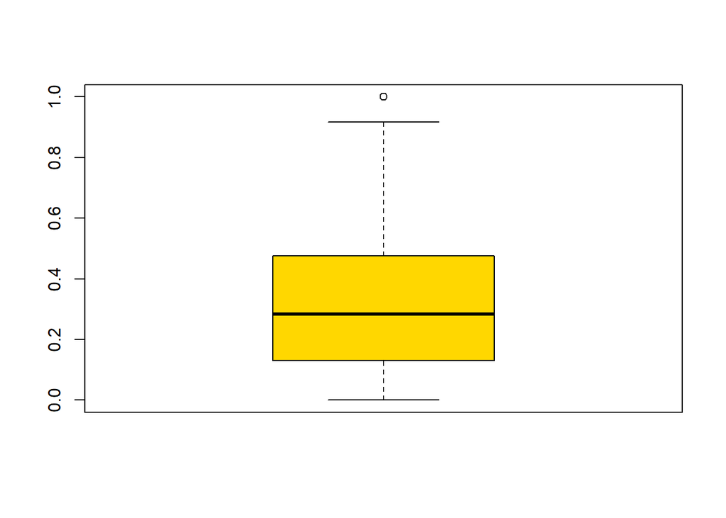

```r
boxplot(data1$pres_bound,col="gold")
```

### Exploratory of consumo response variable

```r
summary(data1$consumo)
```

```
##    Min. 1st Qu.  Median    Mean 3rd Qu.    Max.
##    0.00   31.95   76.90  111.19  146.31 1166.67
```

```r
sum(data1$consumo==0)/length(data1$consumo)
```

```
## [1] 0.153556
```

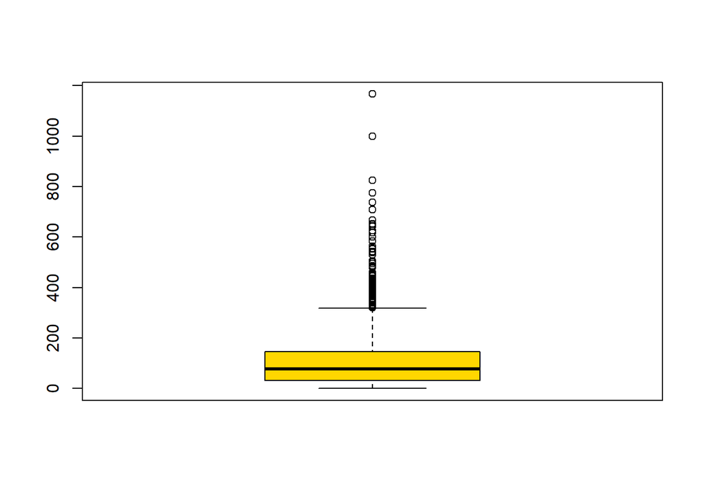

```r
boxplot(data1$consumo,col="gold")
```

### Defining time and season covariables

Seasonal variable

```r
data1$newdate=(data1$DATA)
data1$season=yday(data1$newdate)
# Interesting link: https://data.library.virginia.edu/working-with-dates-and-time-in-r-us## ing-the-lubridate-package/
summary(data1$season)
```

```
##    Min. 1st Qu.  Median    Mean 3rd Qu.    Max.
##     6.0   115.0   200.0   177.4   277.0   345.0
```

Continuous time variable

```r
data1$Time <- julian(data1$newdate, origin = as.Date("2012-07-17"))
summary(data1$Time)
```

```
##    Min. 1st Qu.  Median    Mean 3rd Qu.    Max.
##       0    1019    1755    1711    2554    3380
```

### Exploratory covariables

```
##
##
## Variance inflation factors
##
##                          GVIF
## vazao                1.337227
## TOTAL_RIQUEZA_PEIXES 1.022159
## season               1.260905
## Time                 1.094479
```

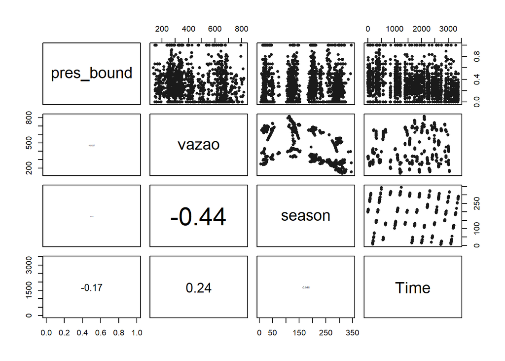

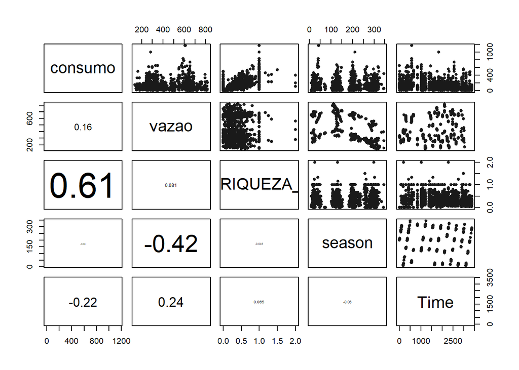

```
##
##  Pearson's product-moment correlation
##
## data:  data1$vazao and data1$season
## t = -19.057, df = 1474, p-value < 2.2e-16
## alternative hypothesis: true correlation is not equal to 0
## 95 percent confidence interval:
##  -0.4846397 -0.4027232
## sample estimates:
##        cor
## -0.4446107
```

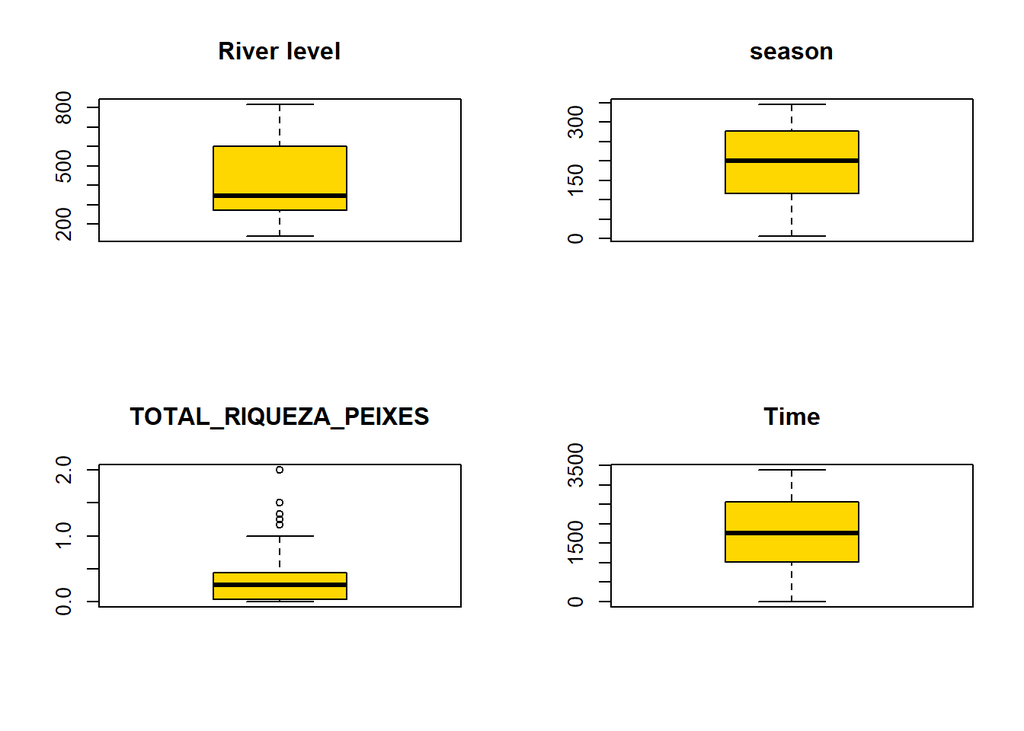

```
##
## DEWATERED_REACH_RURAL      DOWNSTREAM_RURAL      DOWNSTREAM_URBAN
##                   378                   263                   395
##       RESERVOIR_RURAL       RESERVOIR_URBAN
##                   362                   431
```

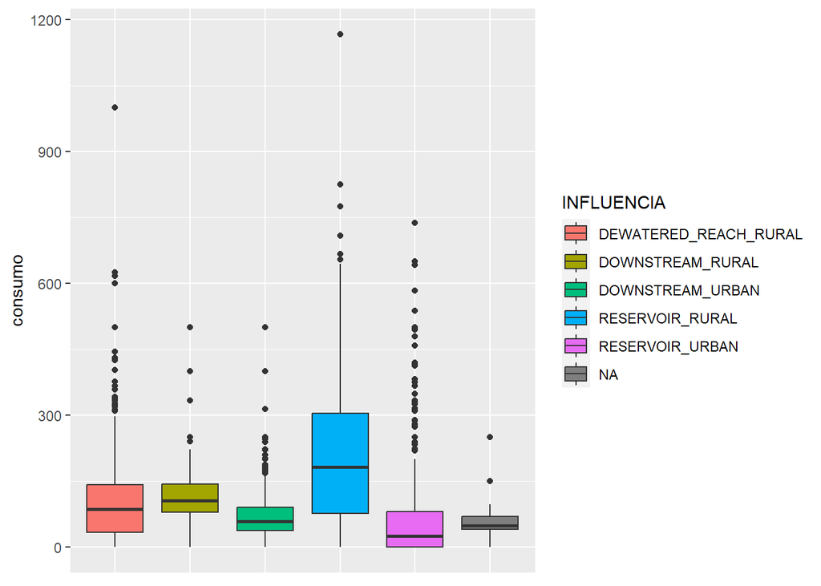

## Models

```r
library(INLA)
```

### INLA models

```r
# Define the new INFLUENCIA variable
influ=(data1$INFLUENCIA)
influ[which(influ=="DEWATERED_REACH_RURAL")] <- NA
influ=as.factor(influ)

N <- nrow(data1)
Xgamma <- data.frame(Intercgamma = rep(1, N),
                    INFLUENCIAgamma   = influ,
                    TOTAL_RIQUEZA_PEIXESgamma=data1$TOTAL_RIQUEZA_PEIXES,
                    seasongamma=data1$season,
                    Timegamma=data1$Time,
                    vazaogamma=data1$vazao,
                    grouped_Timegamma = inla.group(data1$Time,n=10),
                    grouped_seasongamma =  inla.group(data1$season,n=10),
                    grouped_vazaogamma = inla.group(data1$vazao,n=8),
                    grouped_riqueza_gamma =inla.group(data1$TOTAL_RIQUEZA_PEIXES,n=15))


Xbeta <- data.frame(Intercbeta = rep(1, N),
                    INFLUENCIAbeta   = influ,
                    TOTAL_RIQUEZA_PEIXESbeta=data1$TOTAL_RIQUEZA_PEIXES,
                    seasonbeta=data1$season,
                    Timebeta=data1$Time,
                    vazaobeta=data1$vazao,
                    grouped_Timebeta = inla.group(data1$Time,n=10),
                    grouped_seasonbeta = inla.group(data1$season,n=10),
                    grouped_vazaobeta = inla.group(data1$vazao,n=8),
                    grouped_riqueza_beta = inla.group(data1$TOTAL_RIQUEZA_PEIXES,n=15) )
```

```r
Stackgamma <- inla.stack(
  tag  = "FitGamma",
  data = list(AllY = cbind(data1$consumopos, NA)),
  A    = list(1),
  effects = list(
    list(Xgamma = Xgamma)))


Stackbeta <- inla.stack(
  tag  = "FitBeta",
  data = list(AllY = cbind(NA, data1$pres_bound)),
  A    = list(1),
  effects = list(
    list(Xbeta = Xbeta)))

# Combined stack
Stack4 <- inla.stack(Stackgamma,Stackbeta)
```

#### Model without vazao

```r
f4 <- AllY~ -1+
  Intercbeta+
  f(INFLUENCIAbeta, model = "iid",hyper = list(prec =    list(initial    =log(10^{-5}), fixed =TRUE))) +
  f(grouped_Timebeta,model = "rw2")+
 # f(grouped_vazaobeta, model = "rw2")+
  f(grouped_seasonbeta,cyclic=T, model = "rw2")+


  Intercgamma +
  f(INFLUENCIAgamma, model = "iid",hyper = list(prec =   list(initial =     log(10^{-5}),fixed=TRUE)))+
  f(grouped_Timegamma, model = "rw2")+
 # f(grouped_vazaogamma, model = "rw2")+
  f(grouped_riqueza_gamma, model = "rw2")+
  f(grouped_seasongamma,cyclic=T, model = "rw2")

I4 <- inla(f4,
           family = c("gamma", "beta"),
           data = inla.stack.data(Stack4),
           control.compute = list(dic = TRUE, waic = TRUE,return.marginals.predictor=TRUE),
           control.predictor = list(
             A = inla.stack.A(Stack4),compute=TRUE),verbose = TRUE,num.threads = 1
            )
summary(I4)
```

```
##
## Call:
##    c("inla.core(formula = formula, family = family, contrasts = contrasts,
##    ", " data = data, quantiles = quantiles, E = E, offset = offset, ", "
##    scale = scale, weights = weights, Ntrials = Ntrials, strata = strata,
##    ", " lp.scale = lp.scale, link.covariates = link.covariates, verbose =
##    verbose, ", " lincomb = lincomb, selection = selection, control.compute
##    = control.compute, ", " control.predictor = control.predictor,
##    control.family = control.family, ", " control.inla = control.inla,
##    control.fixed = control.fixed, ", " control.mode = control.mode,
##    control.expert = control.expert, ", " control.hazard = control.hazard,
##    control.lincomb = control.lincomb, ", " control.update =
##    control.update, control.lp.scale = control.lp.scale, ", "
##    control.pardiso = control.pardiso, only.hyperparam = only.hyperparam,
##    ", " inla.call = inla.call, inla.arg = inla.arg, num.threads =
##    num.threads, ", " blas.num.threads = blas.num.threads, keep = keep,
##    working.directory = working.directory, ", " silent = silent, inla.mode
##    = inla.mode, safe = FALSE, debug = debug, ", " .parent.frame =
##    .parent.frame)")
## Time used:
##     Pre = 4.25, Running = 26.6, Post = 1.36, Total = 32.2
## Fixed effects:
##               mean    sd 0.025quant 0.5quant 0.975quant   mode kld
## Intercbeta  -0.707 0.068     -0.842   -0.707     -0.574 -0.706   0
## Intercgamma  5.122 0.047      5.030    5.122      5.214  5.122   0
##
## Random effects:
##   Name     Model
##     INFLUENCIAbeta IID model
##    grouped_Timebeta RW2 model
##    grouped_seasonbeta RW2 model
##    INFLUENCIAgamma IID model
##    grouped_Timegamma RW2 model
##    grouped_riqueza_gamma RW2 model
##    grouped_seasongamma RW2 model
##
## Model hyperparameters:
##                                                      mean       sd 0.025quant
## Precision parameter for the Gamma observations   3.42e+00 1.17e-01   3.19e+00
## precision parameter for the beta observations[2] 1.18e+00 3.30e-02   1.11e+00
```

[output cut: 10 more lines]

```
## Precision for grouped_Timegamma                  8.37e+04   2.50e+05 6.27e+04
## Precision for grouped_riqueza_gamma              7.50e-02   3.06e-01 4.90e-02
## Precision for grouped_seasongamma                1.19e+03   1.51e+04 3.88e+02
##
## Deviance Information Criterion (DIC) ...............: 14774.70
## Deviance Information Criterion (DIC, saturated) ....: 3267.06
## Effective number of parameters .....................: 47.15
##
## Watanabe-Akaike information criterion (WAIC) ...: 14785.21
## Effective number of parameters .................: 55.64
##
## Marginal log-Likelihood:  -7484.87
##  is computed
## Posterior summaries for the linear predictor and the fitted values are computed
## (Posterior marginals needs also 'control.compute=list(return.marginals.predictor=TRUE)')
```

```r
vec1=c(I4$waic$waic,
I4$dic$dic)
round(I4$summary.fixed,3)
```

```
##               mean    sd 0.025quant 0.5quant 0.975quant   mode kld
## Intercbeta  -0.707 0.068     -0.842   -0.707     -0.574 -0.706   0
## Intercgamma  5.122 0.047      5.030    5.122      5.214  5.122   0
```

```r
I4$summary.random$INFLUENCIAbeta
```

```
##                 ID        mean         sd 0.025quant   0.5quant 0.975quant
## 1 DOWNSTREAM_RURAL  0.54973670 0.09957138  0.3543181  0.5497867  0.7448727
## 2 DOWNSTREAM_URBAN  0.01731469 0.08676501 -0.1528516  0.0173166  0.1874701
## 3  RESERVOIR_RURAL  0.57484916 0.08932651  0.3995527  0.5748890  0.7499203
## 4  RESERVOIR_URBAN -0.44639391 0.08488991 -0.6128686 -0.4463958 -0.2799077
##          mode          kld
## 1  0.54988672 7.477564e-11
## 2  0.01732042 5.187298e-11
## 3  0.57496861 7.302319e-11
## 4 -0.44639856 6.020347e-11
```

```r
I4$summary.random$INFLUENCIAgamma
```

```
##                 ID       mean         sd 0.025quant   0.5quant  0.975quant
## 1 DOWNSTREAM_RURAL -0.2597192 0.04655865 -0.3510394 -0.2597187 -0.16840154
## 2 DOWNSTREAM_URBAN -0.1753086 0.04180230 -0.2572956 -0.1753096 -0.09331567
## 3  RESERVOIR_RURAL  0.3360011 0.04415258  0.2494053  0.3359998  0.42260486
## 4  RESERVOIR_URBAN -0.2151640 0.04453096 -0.3025092 -0.2151628 -0.12782569
##         mode          kld
## 1 -0.2597178 1.597627e-11
## 2 -0.1753115 1.605879e-11
## 3  0.3359971 1.601906e-11
## 4 -0.2151600 1.645482e-11
```

#### Model without INFLUENCIA

```r
f5 <- AllY~ -1+
  Intercbeta+
  #f(INFLUENCIAbeta, model = "iid",hyper = list(prec =    list(initial    =log(10^{-5}), fixed =TRUE))) +
  f(grouped_Timebeta,model = "rw2")+
  f(grouped_vazaobeta, model = "rw2")+
  f(grouped_seasonbeta,cyclic=T, model = "rw2")+


  Intercgamma +
  #f(INFLUENCIAgamma, model = "iid",hyper = list(prec =   list(initial =   log(10^{-5}),fixed=TRUE)))+
  f(grouped_Timegamma, model = "rw2")+
  f(grouped_vazaogamma, model = "rw2")+
  f(grouped_riqueza_gamma, model = "rw2")+
  f(grouped_seasongamma,cyclic=T, model = "rw2")

I5 <- inla(f5,
           family = c("gamma", "beta"),
           data = inla.stack.data(Stack4),
           control.compute = list(dic = TRUE, waic = TRUE,return.marginals.predictor=TRUE),
           control.predictor = list(
             A = inla.stack.A(Stack4),compute=TRUE),verbose = TRUE,num.threads = 1
            )
summary(I5)
```

```
##
## Call:
##    c("inla.core(formula = formula, family = family, contrasts = contrasts,
##    ", " data = data, quantiles = quantiles, E = E, offset = offset, ", "
##    scale = scale, weights = weights, Ntrials = Ntrials, strata = strata,
##    ", " lp.scale = lp.scale, link.covariates = link.covariates, verbose =
##    verbose, ", " lincomb = lincomb, selection = selection, control.compute
##    = control.compute, ", " control.predictor = control.predictor,
##    control.family = control.family, ", " control.inla = control.inla,
##    control.fixed = control.fixed, ", " control.mode = control.mode,
##    control.expert = control.expert, ", " control.hazard = control.hazard,
##    control.lincomb = control.lincomb, ", " control.update =
##    control.update, control.lp.scale = control.lp.scale, ", "
##    control.pardiso = control.pardiso, only.hyperparam = only.hyperparam,
##    ", " inla.call = inla.call, inla.arg = inla.arg, num.threads =
##    num.threads, ", " blas.num.threads = blas.num.threads, keep = keep,
##    working.directory = working.directory, ", " silent = silent, inla.mode
##    = inla.mode, safe = FALSE, debug = debug, ", " .parent.frame =
##    .parent.frame)")
## Time used:
##     Pre = 3.47, Running = 49.4, Post = 1.79, Total = 54.7
## Fixed effects:
##               mean    sd 0.025quant 0.5quant 0.975quant   mode kld
## Intercbeta  -0.648 0.049     -0.746   -0.648     -0.554 -0.647   0
## Intercgamma  5.142 0.040      5.064    5.142      5.219  5.142   0
##
## Random effects:
##   Name     Model
##     grouped_Timebeta RW2 model
##    grouped_vazaobeta RW2 model
##    grouped_seasonbeta RW2 model
##    grouped_Timegamma RW2 model
##    grouped_vazaogamma RW2 model
##    grouped_riqueza_gamma RW2 model
##    grouped_seasongamma RW2 model
##
## Model hyperparameters:
##                                                      mean       sd 0.025quant
## Precision parameter for the Gamma observations   3.13e+00 1.07e-01   2.93e+00
## precision parameter for the beta observations[2] 1.09e+00 3.00e-02   1.03e+00
```

[output cut: 14 more lines]

```
## Precision for grouped_vazaogamma                 7.54e+04   1.95e+05 5.93e+04
## Precision for grouped_riqueza_gamma              7.60e-02   2.16e-01 5.60e-02
## Precision for grouped_seasongamma                1.49e+04   7.24e+04 4.03e+03
##
## Deviance Information Criterion (DIC) ...............: 15064.00
## Deviance Information Criterion (DIC, saturated) ....: 3262.64
## Effective number of parameters .....................: 50.07
##
## Watanabe-Akaike information criterion (WAIC) ...: 15076.63
## Effective number of parameters .................: 59.98
##
## Marginal log-Likelihood:  -7527.06
##  is computed
## Posterior summaries for the linear predictor and the fitted values are computed
## (Posterior marginals needs also 'control.compute=list(return.marginals.predictor=TRUE)')
```

```r
vec2=c(I5$waic$waic,
I5$dic$dic)
round(I5$summary.fixed,3)
```

```
##               mean    sd 0.025quant 0.5quant 0.975quant   mode kld
## Intercbeta  -0.648 0.049     -0.746   -0.648     -0.554 -0.647   0
## Intercgamma  5.142 0.040      5.064    5.142      5.219  5.142   0
```

#### Model without vazao and Time linear

```r
f6 <- AllY~ -1+
  Intercbeta+
  f(INFLUENCIAbeta, model = "iid",hyper = list(prec =    list(initial    =log(10^{-5}), fixed =TRUE))) +
  #f(grouped_Timebeta,model = "rw2")+
  Timebeta+
  #f(grouped_vazaobeta, model = "rw2")+
  f(grouped_seasonbeta,cyclic=T, model = "rw2")+


  Intercgamma +
  f(INFLUENCIAgamma, model = "iid",hyper = list(prec =   list(initial =   log(10^{-5}),fixed=TRUE)))+
  #f(grouped_Timegamma, model = "rw2")+
  Timegamma+
  #f(grouped_vazaogamma, model = "rw2")+
  f(grouped_riqueza_gamma, model = "rw2")+
  f(grouped_seasongamma,cyclic=T, model = "rw2")

I6 <- inla(f6,
           family = c("gamma", "beta"),
           data = inla.stack.data(Stack4),
           control.compute = list(dic = TRUE, waic = TRUE,return.marginals.predictor=TRUE),
           control.predictor = list(
             A = inla.stack.A(Stack4),compute=TRUE),verbose = TRUE,num.threads = 1
            )
summary(I6)
```

```
##
## Call:
##    c("inla.core(formula = formula, family = family, contrasts = contrasts,
##    ", " data = data, quantiles = quantiles, E = E, offset = offset, ", "
##    scale = scale, weights = weights, Ntrials = Ntrials, strata = strata,
##    ", " lp.scale = lp.scale, link.covariates = link.covariates, verbose =
##    verbose, ", " lincomb = lincomb, selection = selection, control.compute
##    = control.compute, ", " control.predictor = control.predictor,
##    control.family = control.family, ", " control.inla = control.inla,
##    control.fixed = control.fixed, ", " control.mode = control.mode,
##    control.expert = control.expert, ", " control.hazard = control.hazard,
##    control.lincomb = control.lincomb, ", " control.update =
##    control.update, control.lp.scale = control.lp.scale, ", "
##    control.pardiso = control.pardiso, only.hyperparam = only.hyperparam,
##    ", " inla.call = inla.call, inla.arg = inla.arg, num.threads =
##    num.threads, ", " blas.num.threads = blas.num.threads, keep = keep,
##    working.directory = working.directory, ", " silent = silent, inla.mode
##    = inla.mode, safe = FALSE, debug = debug, ", " .parent.frame =
##    .parent.frame)")
## Time used:
##     Pre = 4.9, Running = 9.63, Post = 0.905, Total = 15.4
## Fixed effects:
##               mean    sd 0.025quant 0.5quant 0.975quant   mode kld
## Intercbeta  -0.522 0.081     -0.682   -0.522     -0.363 -0.522   0
## Timebeta     0.000 0.000      0.000    0.000      0.000  0.000   0
## Intercgamma  5.229 0.043      5.144    5.229      5.314  5.229   0
## Timegamma    0.000 0.000      0.000    0.000      0.000  0.000   0
##
## Random effects:
##   Name     Model
##     INFLUENCIAbeta IID model
##    grouped_seasonbeta RW2 model
##    INFLUENCIAgamma IID model
##    grouped_riqueza_gamma RW2 model
##    grouped_seasongamma RW2 model
##
## Model hyperparameters:
##                                                      mean       sd 0.025quant
## Precision parameter for the Gamma observations      3.399 1.16e-01      3.175
## precision parameter for the beta observations[2]    1.152 3.00e-02      1.091
## Precision for grouped_seasonbeta                 7869.425 2.00e+05     10.566
## Precision for grouped_riqueza_gamma                 0.085 4.90e-02      0.024
## Precision for grouped_seasongamma                1407.702 7.22e+03     38.436
##                                                  0.5quant 0.975quant   mode
## Precision parameter for the Gamma observations      3.398   3.63e+00  3.395
## precision parameter for the beta observations[2]    1.153   1.21e+00  1.157
## Precision for grouped_seasonbeta                  226.124   3.78e+04 20.401
## Precision for grouped_riqueza_gamma                 0.074   2.11e-01  0.055
## Precision for grouped_seasongamma                 324.748   9.43e+03 79.946
##
## Deviance Information Criterion (DIC) ...............: 14790.19
## Deviance Information Criterion (DIC, saturated) ....: 3240.26
## Effective number of parameters .....................: 28.59
##
## Watanabe-Akaike information criterion (WAIC) ...: 14798.42
## Effective number of parameters .................: 35.43
##
## Marginal log-Likelihood:  -7573.58
##  is computed
## Posterior summaries for the linear predictor and the fitted values are computed
## (Posterior marginals needs also 'control.compute=list(return.marginals.predictor=TRUE)')
```

```r
vec3=c(I6$waic$waic,
I6$dic$dic)
round(I6$summary.fixed,3)
```

```
##               mean    sd 0.025quant 0.5quant 0.975quant   mode kld
## Intercbeta  -0.522 0.081     -0.682   -0.522     -0.363 -0.522   0
## Timebeta     0.000 0.000      0.000    0.000      0.000  0.000   0
## Intercgamma  5.229 0.043      5.144    5.229      5.314  5.229   0
## Timegamma    0.000 0.000      0.000    0.000      0.000  0.000   0
```

```r
I6$summary.random$INFLUENCIAbeta
```

```
##                 ID         mean         sd 0.025quant     0.5quant 0.975quant
## 1 DOWNSTREAM_RURAL  0.535457839 0.09854182  0.3421003  0.535493482  0.7286141
## 2 DOWNSTREAM_URBAN  0.005016832 0.08645245 -0.1645353  0.005018328  0.1745605
## 3  RESERVOIR_RURAL  0.544980811 0.08954011  0.3692757  0.545017039  0.7204814
## 4  RESERVOIR_URBAN -0.470362281 0.08402111 -0.6351021 -0.470375200 -0.3055490
##          mode          kld
## 1  0.53556517 6.543620e-11
## 2  0.00502136 5.186882e-11
## 3  0.54508997 6.923064e-11
## 4 -0.47040067 6.259413e-11
```

```r
I6$summary.random$INFLUENCIAgamma
```

```
##                 ID       mean         sd 0.025quant   0.5quant  0.975quant
## 1 DOWNSTREAM_RURAL -0.2515631 0.04618174 -0.3421435 -0.2515625 -0.16098605
## 2 DOWNSTREAM_URBAN -0.1753220 0.04167086 -0.2570517 -0.1753226 -0.09358913
## 3  RESERVOIR_RURAL  0.3400665 0.04385050  0.2540611  0.3400662  0.42607363
## 4  RESERVOIR_URBAN -0.2097331 0.04411771 -0.2962699 -0.2097310 -0.12320926
##         mode          kld
## 1 -0.2515612 1.865219e-11
## 2 -0.1753241 1.869570e-11
## 3  0.3400651 1.879001e-11
## 4 -0.2097277 1.927074e-11
```

#### Model without vazao and Season

```r
f7 <- AllY~ -1+
  Intercbeta+
  f(INFLUENCIAbeta, model = "iid",hyper = list(prec =    list(initial    =log(10^{-5}), fixed =TRUE))) +
  f(grouped_Timebeta,model = "rw2")+
 # f(grouped_vazaobeta, model = "rw2")+
 # f(grouped_seasonbeta,cyclic=T, model = "rw2")+


  Intercgamma +
  f(INFLUENCIAgamma, model = "iid",hyper = list(prec =   list(initial =   log(10^{-5}),fixed=TRUE)))+
  f(grouped_Timegamma, model = "rw2")+
 # f(grouped_vazaogamma, model = "rw2")+
  f(grouped_riqueza_gamma, model = "rw2")
 # f(grouped_seasongamma,cyclic=T, model = "rw2")

I7 <- inla(f7,
           family = c("gamma", "beta"),
           data = inla.stack.data(Stack4),
           control.compute = list(dic = TRUE, waic = TRUE,return.marginals.predictor=TRUE),
           control.predictor = list(
             A = inla.stack.A(Stack4),compute=TRUE),verbose = TRUE,num.threads = 1
            )
summary(I7)
```

```
##
## Call:
##    c("inla.core(formula = formula, family = family, contrasts = contrasts,
##    ", " data = data, quantiles = quantiles, E = E, offset = offset, ", "
##    scale = scale, weights = weights, Ntrials = Ntrials, strata = strata,
##    ", " lp.scale = lp.scale, link.covariates = link.covariates, verbose =
##    verbose, ", " lincomb = lincomb, selection = selection, control.compute
##    = control.compute, ", " control.predictor = control.predictor,
##    control.family = control.family, ", " control.inla = control.inla,
##    control.fixed = control.fixed, ", " control.mode = control.mode,
##    control.expert = control.expert, ", " control.hazard = control.hazard,
##    control.lincomb = control.lincomb, ", " control.update =
##    control.update, control.lp.scale = control.lp.scale, ", "
##    control.pardiso = control.pardiso, only.hyperparam = only.hyperparam,
##    ", " inla.call = inla.call, inla.arg = inla.arg, num.threads =
##    num.threads, ", " blas.num.threads = blas.num.threads, keep = keep,
##    working.directory = working.directory, ", " silent = silent, inla.mode
##    = inla.mode, safe = FALSE, debug = debug, ", " .parent.frame =
##    .parent.frame)")
## Time used:
##     Pre = 2.89, Running = 10.9, Post = 0.856, Total = 14.6
## Fixed effects:
##               mean    sd 0.025quant 0.5quant 0.975quant   mode kld
## Intercbeta  -0.690 0.064     -0.815   -0.690     -0.565 -0.690   0
## Intercgamma  5.113 0.046      5.022    5.113      5.204  5.113   0
##
## Random effects:
##   Name     Model
##     INFLUENCIAbeta IID model
##    grouped_Timebeta RW2 model
##    INFLUENCIAgamma IID model
##    grouped_Timegamma RW2 model
##    grouped_riqueza_gamma RW2 model
##
## Model hyperparameters:
##                                                      mean       sd 0.025quant
## Precision parameter for the Gamma observations   3.38e+00 1.16e-01   3.16e+00
## precision parameter for the beta observations[2] 1.16e+00 3.20e-02   1.10e+00
## Precision for grouped_Timebeta                   1.06e+05 4.68e+04   3.90e+04
## Precision for grouped_Timegamma                  1.06e+05 4.70e+04   3.93e+04
## Precision for grouped_riqueza_gamma              9.20e-02 5.20e-02   2.50e-02
##                                                  0.5quant 0.975quant     mode
## Precision parameter for the Gamma observations   3.38e+00   3.62e+00 3.38e+00
## precision parameter for the beta observations[2] 1.16e+00   1.23e+00 1.16e+00
## Precision for grouped_Timebeta                   9.77e+04   2.19e+05 8.22e+04
## Precision for grouped_Timegamma                  9.81e+04   2.21e+05 8.25e+04
## Precision for grouped_riqueza_gamma              8.10e-02   2.23e-01 6.10e-02
##
## Deviance Information Criterion (DIC) ...............: 14805.63
## Deviance Information Criterion (DIC, saturated) ....: 3259.05
## Effective number of parameters .....................: 36.96
##
## Watanabe-Akaike information criterion (WAIC) ...: 14813.26
## Effective number of parameters .................: 42.96
##
## Marginal log-Likelihood:  -7480.06
##  is computed
## Posterior summaries for the linear predictor and the fitted values are computed
## (Posterior marginals needs also 'control.compute=list(return.marginals.predictor=TRUE)')
```

```r
vec4=c(I7$waic$waic,
I7$dic$dic)
round(I7$summary.fixed,3)
```

```
##               mean    sd 0.025quant 0.5quant 0.975quant   mode kld
## Intercbeta  -0.690 0.064     -0.815   -0.690     -0.565 -0.690   0
## Intercgamma  5.113 0.046      5.022    5.113      5.204  5.113   0
```

```r
I7$summary.random$INFLUENCIAbeta
```

```
##                 ID        mean         sd 0.025quant    0.5quant 0.975quant
## 1 DOWNSTREAM_RURAL  0.55737771 0.09911842  0.3628712  0.55741958  0.7516473
## 2 DOWNSTREAM_URBAN  0.02327817 0.08654392 -0.1464550  0.02328024  0.1929997
## 3  RESERVOIR_RURAL  0.57380717 0.08914388  0.3988471  0.57385442  0.7485000
## 4  RESERVOIR_URBAN -0.47359605 0.08404862 -0.6383563 -0.47362189 -0.3086896
##          mode          kld
## 1  0.55750336 6.941767e-11
## 2  0.02328438 5.169163e-11
## 3  0.57394892 7.908570e-11
## 4 -0.47367361 6.180668e-11
```

```r
I7$summary.random$INFLUENCIAgamma
```

```
##                 ID       mean         sd 0.025quant   0.5quant  0.975quant
## 1 DOWNSTREAM_RURAL -0.2594667 0.04666516 -0.3509971 -0.2594661 -0.16793967
## 2 DOWNSTREAM_URBAN -0.1731046 0.04193031 -0.2553449 -0.1731051 -0.09086131
## 3  RESERVOIR_RURAL  0.3394396 0.04431586  0.2525196  0.3394393  0.42636118
## 4  RESERVOIR_URBAN -0.2087273 0.04445612 -0.2959229 -0.2087274 -0.12153105
##         mode          kld
## 1 -0.2594649 1.369046e-11
## 2 -0.1731061 1.370684e-11
## 3  0.3394388 1.369651e-11
## 4 -0.2087275 1.368747e-11
```

#### Model without INFLUENCIA and season

```r
f8 <- AllY~ -1+
  Intercbeta+
  #f(INFLUENCIAbeta, model = "iid",hyper = list(prec =    list(initial    =log(10^{-5}), fixed =TRUE))) +
  f(grouped_Timebeta,model = "rw2")+
  f(grouped_vazaobeta, model = "rw2")+
  #f(grouped_seasonbeta,cyclic=T, model = "rw2")+


  Intercgamma +
  #f(INFLUENCIAgamma, model = "iid",hyper = list(prec =   list(initial =   log(10^{-5}),fixed=TRUE)))+
  f(grouped_Timegamma, model = "rw2")+
  f(grouped_vazaogamma, model = "rw2")+
  f(grouped_riqueza_gamma, model = "rw2")
 # f(grouped_seasongamma,cyclic=T, model = "rw2")

I8 <- inla(f8,
           family = c("gamma", "beta"),
           data = inla.stack.data(Stack4),
           control.compute = list(dic = TRUE, waic = TRUE,return.marginals.predictor=TRUE),
           control.predictor = list(
             A = inla.stack.A(Stack4),compute=TRUE),verbose = TRUE,num.threads = 1
            )
summary(I8)
```

```
##
## Call:
##    c("inla.core(formula = formula, family = family, contrasts = contrasts,
##    ", " data = data, quantiles = quantiles, E = E, offset = offset, ", "
##    scale = scale, weights = weights, Ntrials = Ntrials, strata = strata,
##    ", " lp.scale = lp.scale, link.covariates = link.covariates, verbose =
##    verbose, ", " lincomb = lincomb, selection = selection, control.compute
##    = control.compute, ", " control.predictor = control.predictor,
##    control.family = control.family, ", " control.inla = control.inla,
##    control.fixed = control.fixed, ", " control.mode = control.mode,
##    control.expert = control.expert, ", " control.hazard = control.hazard,
##    control.lincomb = control.lincomb, ", " control.update =
##    control.update, control.lp.scale = control.lp.scale, ", "
##    control.pardiso = control.pardiso, only.hyperparam = only.hyperparam,
##    ", " inla.call = inla.call, inla.arg = inla.arg, num.threads =
##    num.threads, ", " blas.num.threads = blas.num.threads, keep = keep,
##    working.directory = working.directory, ", " silent = silent, inla.mode
##    = inla.mode, safe = FALSE, debug = debug, ", " .parent.frame =
##    .parent.frame)")
## Time used:
##     Pre = 2.95, Running = 24.5, Post = 1.29, Total = 28.7
## Fixed effects:
##               mean   sd 0.025quant 0.5quant 0.975quant   mode kld
## Intercbeta  -0.608 0.04     -0.687   -0.608     -0.530 -0.609   0
## Intercgamma  5.140 0.04      5.062    5.140      5.218  5.141   0
##
## Random effects:
##   Name     Model
##     grouped_Timebeta RW2 model
##    grouped_vazaobeta RW2 model
##    grouped_Timegamma RW2 model
##    grouped_vazaogamma RW2 model
##    grouped_riqueza_gamma RW2 model
##
## Model hyperparameters:
##                                                      mean       sd 0.025quant
## Precision parameter for the Gamma observations   3.13e+00 1.09e-01   2.93e+00
## precision parameter for the beta observations[2] 1.06e+00 3.00e-02   1.01e+00
## Precision for grouped_Timebeta                   1.00e+05 4.46e+04   3.48e+04
## Precision for grouped_vazaobeta                  8.75e+04 4.12e+04   2.82e+04
```

[output cut: 8 more lines]

```
## Precision for grouped_Timegamma                  9.43e+04   2.08e+05 7.94e+04
## Precision for grouped_vazaogamma                 8.55e+04   1.97e+05 7.01e+04
## Precision for grouped_riqueza_gamma              6.80e-02   2.32e-01 4.80e-02
##
## Deviance Information Criterion (DIC) ...............: 15100.77
## Deviance Information Criterion (DIC, saturated) ....: 3246.78
## Effective number of parameters .....................: 42.82
##
## Watanabe-Akaike information criterion (WAIC) ...: 15111.30
## Effective number of parameters .................: 50.87
##
## Marginal log-Likelihood:  -7524.25
##  is computed
## Posterior summaries for the linear predictor and the fitted values are computed
## (Posterior marginals needs also 'control.compute=list(return.marginals.predictor=TRUE)')
```

```r
vec5=c(I8$waic$waic,
I8$dic$dic)
round(I8$summary.fixed,3)
```

```
##               mean   sd 0.025quant 0.5quant 0.975quant   mode kld
## Intercbeta  -0.608 0.04     -0.687   -0.608     -0.530 -0.609   0
## Intercgamma  5.140 0.04      5.062    5.140      5.218  5.141   0
```

#### Summary

```
##                                   waic      dic
## Without vazao                 14785.21 14774.70
## Without Influencia            15076.63 15064.00
## Without vazao and linear time 14798.42 14790.19
## without vazao and season      14813.26 14805.63
## without influencia and season 15111.30 15100.77
```

Best model the model without vazao.

### Plots

#### Trend (beta)

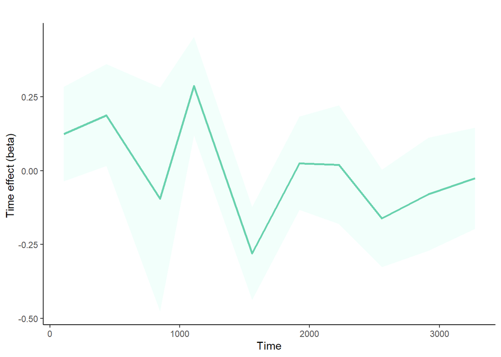

#### Trend (gamma)

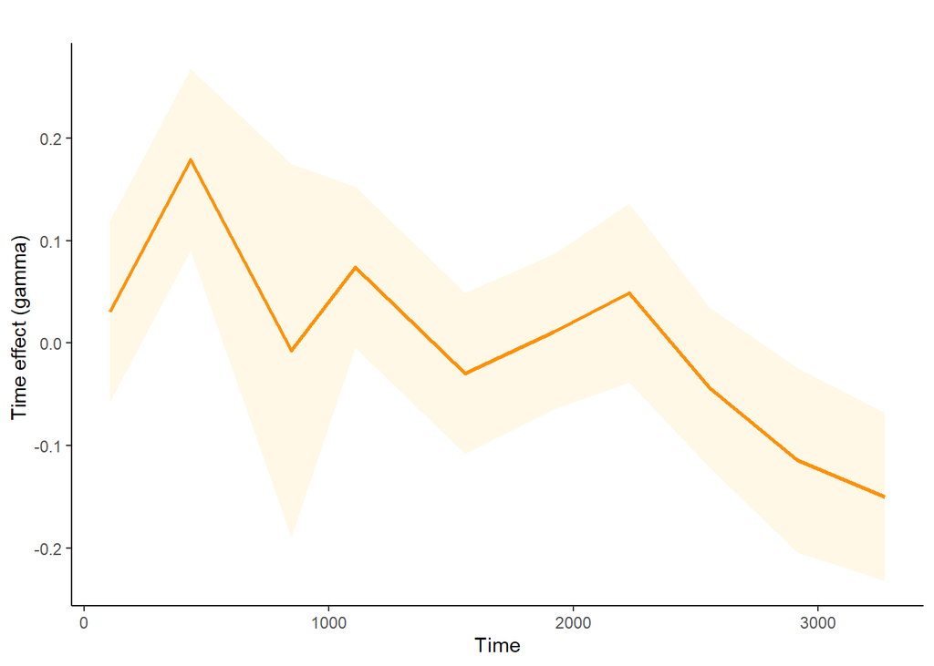

#### Seasonal (beta)

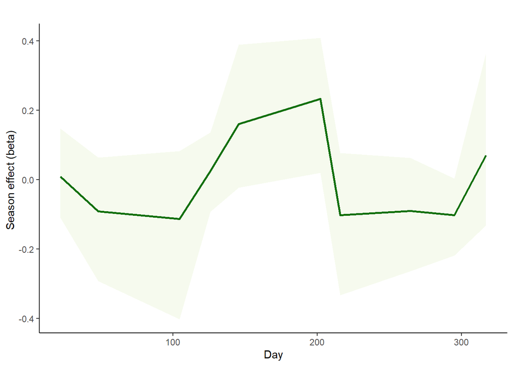

#### Seasonal (gamma)

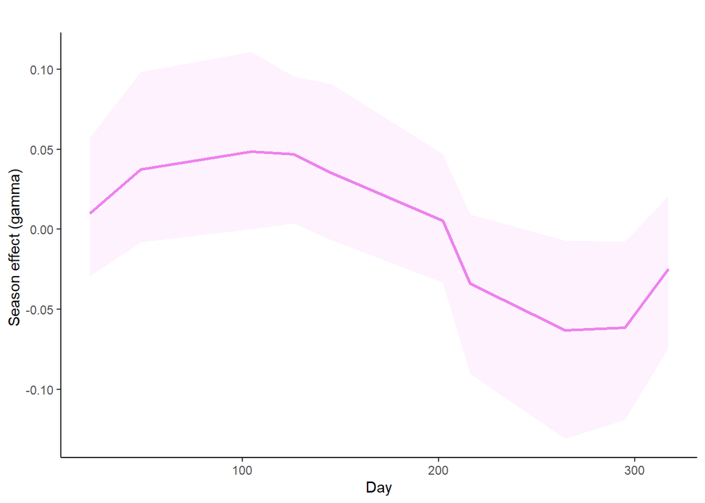

#### Total riqueza

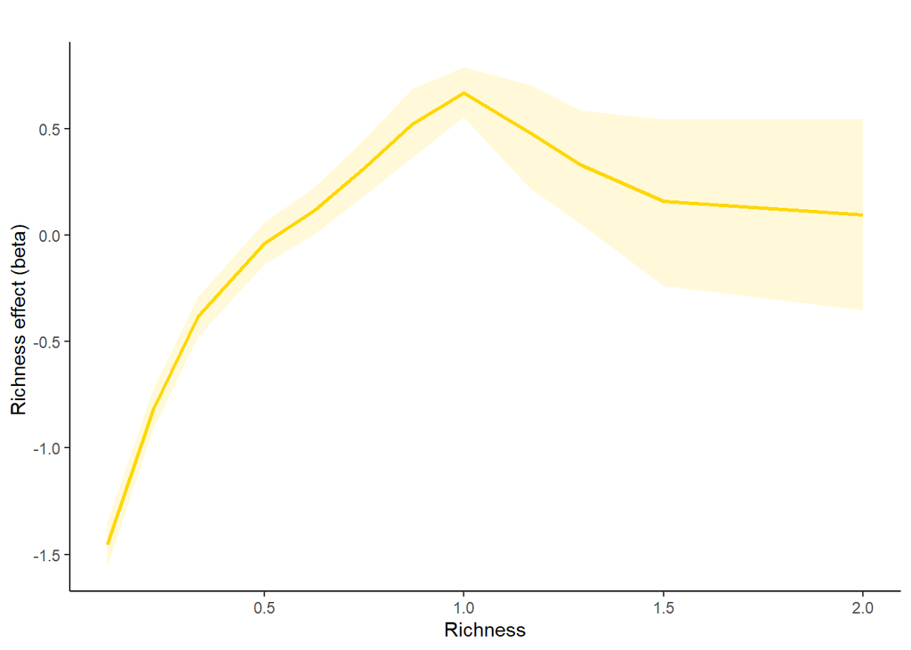

## References

- Smithson M, Verkuilen J (2006). A better lemon squeezer? Maximum likelihood regression with beta-distributed dependent variables. Psychological Methods 11: 54–71.